# 金融大数据第五次作业

151278033 王珂

2017年11月21日

（更新）11月22日  
1.上次交作业错误的理解了题意，我重新首先用matlab函数random出150个二维点，而后将它们导出为txt文件，在MapReduce上运行计算结果；然后将MapReduce程序的输出导入MATLAB当中画图  
首先，用MATLABrandom150个二维点并导出

```
%随机获取150个点
X = [randn(50,2)+ones(50,2);randn(50,2)-ones(50,2);randn(50,2)+[ones(50,1),-ones(50,1)]];
fid = fopen('tt.txt','wt');
for i = 1:size(X,1)
    fprintf(fid,'%f,%f\n',X(i,1),X(i,2));
end
fclose(fid);
plot(X(1),X(2),'k')
```

导出为txt文件

[figure not shown]

MapReduce当中运行

```
bin/hdfs dfs -put data/tt.txt /user
bin/hdfs dfs -ls /user
bin/hadoop jar share/hadoop/mapreduce/kmeans.jar KMeansDriver 2 2 /user/tt.txt output5
bin/hdfs dfs -get output5 output3
cat output3/clusteredInstances/part-m-00000

bin/hdfs dfs -put data/tt.txt /user
bin/hdfs dfs -ls /user
bin/hadoop jar share/hadoop/mapreduce/kmeans.jar KMeansDriver 3 10 /user/tt.txt output6
bin/hdfs dfs -get output6 output4
cat output4/clusteredInstances/part-m-00000

bin/hdfs dfs -put data/tt.txt /user
bin/hdfs dfs -ls /user
bin/hadoop jar share/hadoop/mapreduce/kmeans.jar KMeansDriver 3 2 /user/tt.txt output7
bin/hdfs dfs -get output7 output5
cat output5/clusteredInstances/part-m-00000
```

结果：

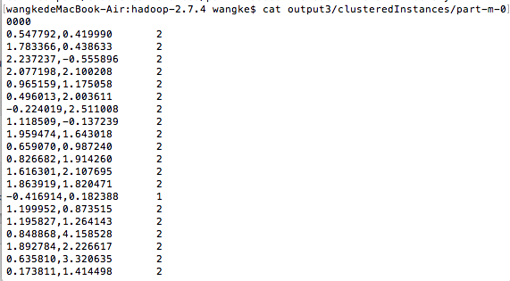

然后导入MATLAB当中

```
load part-m-00000.txt %导入数据
M=part_m_00000;
M1=M(:,1:2); %前两列为点
M2=M(:,3);%最后一列为类别

%画出聚类为1的点。X(Idx==1,1),为第一类的样本的第一个坐标；X(Idx==1,2)为第二类的样本的第二个坐标
plot(M1(M2==1,1),M1(M2==1,2),'r.','MarkerSize',14)
hold on
plot(M1(M2==2,1),M1(M2==2,2),'b.','MarkerSize',14)
hold on
plot(M1(M2==3,1),M1(M2==3,2),'g.','MarkerSize',14)

legend('Cluster 1','Cluster 2','Cluster3','Centroids','Location','NW')
```

画图  
聚类（3，10）

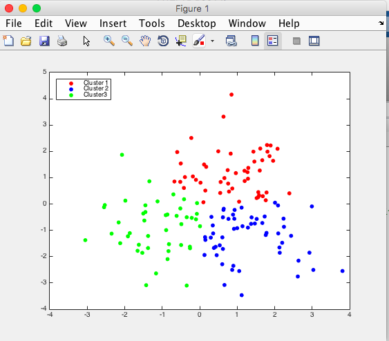

聚类（3，2）

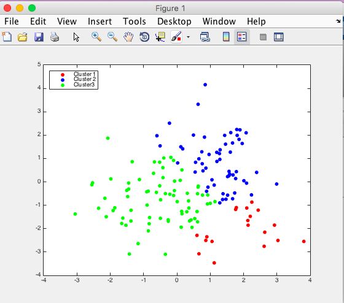

聚类（2，2）

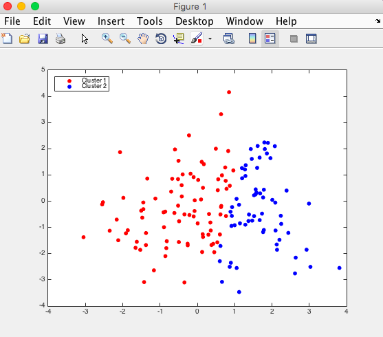

2.在MapReduce上运行6维数据集 运行KMeans的Java代码和小测试集（Java代码较多，已附件，此处不再贴Java代码） 输入参数：聚为两类，迭代10次

```
bin/hdfs dfs -mkdir /user
bin/hdfs dfs -put data/instance.txt /user
bin/hdfs dfs -ls /user
bin/hadoop jar share/hadoop/mapreduce/kmeans.jar KMeansDriver 2 10 /user/instance.txt output3
bin/hdfs dfs -get output3 output2
cat output2/clusteredInstances/part-m-00000
```

结果：  
2,1,3,4,1,4 1  
3,2,5,2,3,5 1  
4,4,4,3,1,5 1  
2,3,1,2,0,3 1  
4,0,1,1,1,5 1  
1,2,3,5,0,1 2  
5,3,2,2,1,3 1  
3,4,1,1,2,1 2  
0,2,3,3,1,4 1  
0,2,5,0,2,2 2  
2,1,4,5,4,3 2  
4,1,4,3,3,2 2  
0,3,2,2,0,1 1  
1,3,1,0,3,0 2  
3,3,4,2,1,3 1  
3,5,3,5,3,2 2  
2,3,2,3,0,1 1  
4,3,3,2,2,3 1  
1,4,3,4,3,1 2  
3,2,3,0,2,5 1  
1,0,2,1,0,4 1  
4,4,3,5,5,4 2  
5,1,4,3,5,2 2  
3,4,4,4,1,1 2  
2,2,4,4,5,5 2  
5,2,0,3,1,3 1  
1,1,3,1,1,3 1  
2,4,2,0,3,5 1  
1,1,1,1,0,4 1  
1,1,4,1,3,0 2  
遇到的问题  
我之前运行hadoop忘记sbin/stop-dfs.sh关闭……结果再次运行的时候已经无法关闭，DataNode和NameNode也都启不启来，报错说local/172.25.169.27正在使用 please shutting down；后来要找到进程号强制杀掉  
http://blog.csdn.net/asia_kobe/article/details/51067769  
一些截图：  
运行程序截图：

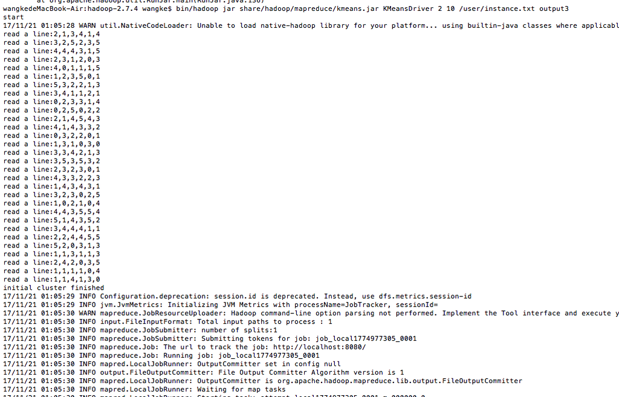

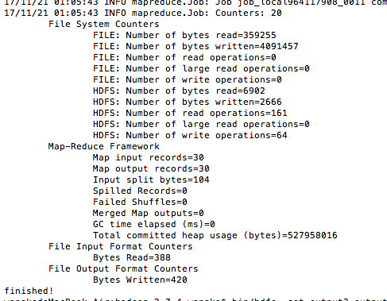

运行结果：

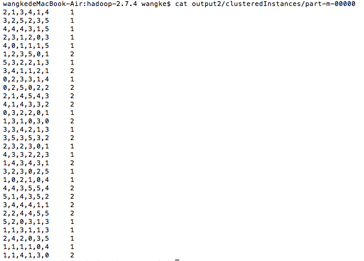

3.MATLAB自带kmeans函数聚类 以下是MATLAB的代码

```
%随机获取150个点
X = [randn(50,2)+ones(50,2);randn(50,2)-ones(50,2);randn(50,2)+[ones(50,1),-ones(50,1)]];
opts = statset('Display','final');

%调用Matlab内部的Kmeans函数

[Idx,Ctrs,SumD,D] = kmeans(X,3,'Replicates',1,'Options',opts);

%画出聚类为1，2，3，4的点
plot(X(Idx==1,1),X(Idx==1,2),'r.','MarkerSize',14)
hold on
plot(X(Idx==2,1),X(Idx==2,2),'b.','MarkerSize',14)
hold on
plot(X(Idx==3,1),X(Idx==3,2),'g.','MarkerSize',14)
%hold on
%plot(X(Idx==4,1),X(Idx==4,2),'y.','MarkerSize',14)

%绘出聚类中心点
plot(Ctrs(:,1),Ctrs(:,2),'kx','MarkerSize',14,'LineWidth',4)
plot(Ctrs(:,1),Ctrs(:,2),'kx','MarkerSize',14,'LineWidth',4)
plot(Ctrs(:,1),Ctrs(:,2),'kx','MarkerSize',14,'LineWidth',4)
%plot(Ctrs(:,1),Ctrs(:,2),'kx','MarkerSize',14,'LineWidth',4)

legend('Cluster 1','Cluster 2','Cluster3','Centroids','Location','NW')
```

运行截图：  
2个类：

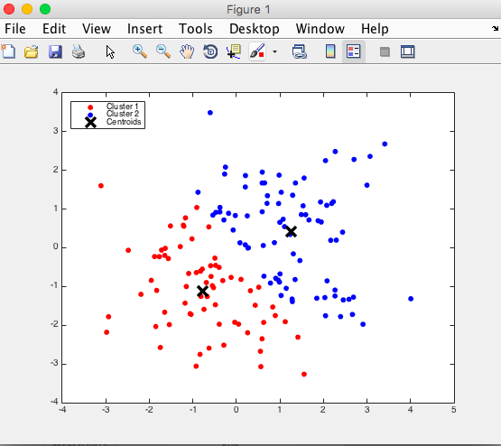

三个类：

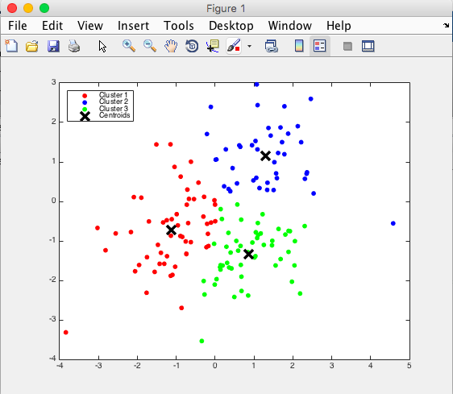

四个类：

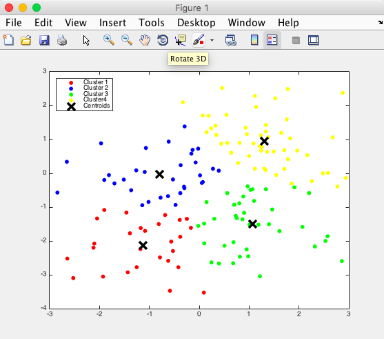

3个类迭代十次：（我觉得好像迭代次数的影响不大）

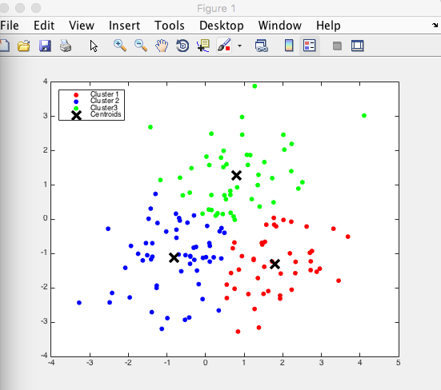